# Lab: NYC Flight Analysis with R & Quarto (Solutions)

Author

Carsten Lange (based on a Gemini draft)

Published

March 21, 2026

# 1 Overview

In this lab, you will explore the `nycflights13` dataset using the **Positron IDE**. Your goal is to move beyond simple coding and produce a **reproducible research report**. You will practice data loading with `rio`, relational joins with the `tidyverse`, and professional formula typesetting with LaTeX.

# 2 Technical Setup

Before you begin, ensure you have the following installed in your environment:

- **Required Packages:** `install.packages(c("rio", "tidyverse", "janitor", "kableExtra"))`
- **Data Files:** Place `flights.csv` and `airports.csv` in the same folder as this `.qmd` file.

# 3 Quarto Document Requirements

Your submission must utilize Quarto’s advanced formatting features: 1. **YAML Header:** Configured for a Table of Contents and numbered sections. 2. **Cross-References:** You must reference at least one Section, Table, and Figure using the `@` syntax. 3. **Code Chunks:** Use `#| label:` and `#| tbl-cap:` or `#| fig-cap:` for all outputs.

# 4 Methodology & Math

In your analysis, you must define your variables. Use **inline math** for variables like the sample mean $\bar{x}$ or the standard deviation $\sigma$.

We will calculate the average delay using the arithmetic mean formula defined in Equation 1:

$$\bar{x} = \frac{1}{n} \sum_{i=1}^{n} x_i
\tag{1}$$

# 5 Task 1: Data Import and Data Engineering

## 5.1 Task 1a: Data Import

We use the `rio` package to load our data. This package simplifies the process by automatically handling the CSV format. The `kable()` command from the `kableExtra` package formats a data frame as a table.

```r
library(rio)
library(tidyverse)
library(janitor)
library(kableExtra)

# INSTRUCTIONS: Load your CSV files here
Flights  = import("Flights.csv") |>
           clean_names("upper_camel")
Airports = import("Airports.csv") |>
           clean_names("upper_camel")

kable(head(Flights))
```

Table 1: Original Flight Data Frame

| Year | Month | Day | DepTime | SchedDepTime | DepDelay | ArrTime | SchedArrTime | ArrDelay | Carrier | Flight | Tailnum | Origin | Dest | AirTime | Distance | Hour | Minute | TimeHour |
| --- | --- | --- | --- | --- | --- | --- | --- | --- | --- | --- | --- | --- | --- | --- | --- | --- | --- | --- |
| 2013 | 1 | 1 | 517 | 515 | 2 | 830 | 819 | 11 | UA | 1545 | N14228 | EWR | IAH | 227 | 1400 | 5 | 15 | 2013-01-01 10:00:00 |
| 2013 | 1 | 1 | 533 | 529 | 4 | 850 | 830 | 20 | UA | 1714 | N24211 | LGA | IAH | 227 | 1416 | 5 | 29 | 2013-01-01 10:00:00 |
| 2013 | 1 | 1 | 542 | 540 | 2 | 923 | 850 | 33 | AA | 1141 | N619AA | JFK | MIA | 160 | 1089 | 5 | 40 | 2013-01-01 10:00:00 |
| 2013 | 1 | 1 | 544 | 545 | -1 | 1004 | 1022 | -18 | B6 | 725 | N804JB | JFK | BQN | 183 | 1576 | 5 | 45 | 2013-01-01 10:00:00 |
| 2013 | 1 | 1 | 554 | 600 | -6 | 812 | 837 | -25 | DL | 461 | N668DN | LGA | ATL | 116 | 762 | 6 | 0 | 2013-01-01 11:00:00 |
| 2013 | 1 | 1 | 554 | 558 | -4 | 740 | 728 | 12 | UA | 1696 | N39463 | EWR | ORD | 150 | 719 | 5 | 58 | 2013-01-01 10:00:00 |

```r
kable(head(Airports))
```

Table 2: Original Airports Data Frame

| Faa | Name | Lat | Lon | Alt | Tz | Dst | Tzone |
| --- | --- | --- | --- | --- | --- | --- | --- |
| 04G | Lansdowne Airport | 41.13047 | -80.61958 | 1044 | -5 | A | America/New_York |
| 06A | Moton Field Municipal Airport | 32.46057 | -85.68003 | 264 | -6 | A | America/Chicago |
| 06C | Schaumburg Regional | 41.98934 | -88.10124 | 801 | -6 | A | America/Chicago |
| 06N | Randall Airport | 41.43191 | -74.39156 | 523 | -5 | A | America/New_York |
| 09J | Jekyll Island Airport | 31.07447 | -81.42778 | 11 | -5 | A | America/New_York |
| 0A9 | Elizabethton Municipal Airport | 36.37122 | -82.17342 | 1593 | -5 | A | America/New_York |

## 5.2 Task 1b: Data Engineering

For both data frames reduce the variables only to the one needed with `select()`!

```r
Flights=Flights |>
        select(Origin, SchedDepTime, DepTime, DepDelay) |>
        drop_na() |>
        filter(DepDelay>=0)
kable(head(Flights))
```

Table 3: Selected Variables from Flight Data Frame

| Origin | SchedDepTime | DepTime | DepDelay |
| --- | --- | --- | --- |
| EWR | 515 | 517 | 2 |
| LGA | 529 | 533 | 4 |
| JFK | 540 | 542 | 2 |
| JFK | 559 | 559 | 0 |
| LGA | 600 | 600 | 0 |
| LGA | 600 | 600 | 0 |

```r
Airports=Airports |>
         select(Faa, Name) |>
         drop_na()
kable(head(Airports))
```

Table 4: Selected Variables from Airports Data Frame

| Faa | Name |
| --- | --- |
| 04G | Lansdowne Airport |
| 06A | Moton Field Municipal Airport |
| 06C | Schaumburg Regional |
| 06N | Randall Airport |
| 09J | Jekyll Island Airport |
| 0A9 | Elizabethton Municipal Airport |

Explain here how the variable `DepDelay` was calculated and comment on the variable types.

# 6 Task 2: Relational Joins

**Note:** You must match the `origin` column from flights to the `faa` column in airports.

```r
# INSTRUCTIONS: Perform the inner_join here
FlightsJoined <- inner_join(Flights, Airports, by = c("Origin" = "Faa")) |>
  rename(NameOrigin=Name)

kable(head(FlightsJoined))
```

Table 5: Sample of Flights Joined with Airport Metadata

| Origin | SchedDepTime | DepTime | DepDelay | NameOrigin |
| --- | --- | --- | --- | --- |
| EWR | 515 | 517 | 2 | Newark Liberty Intl |
| LGA | 529 | 533 | 4 | La Guardia |
| JFK | 540 | 542 | 2 | John F Kennedy Intl |
| JFK | 559 | 559 | 0 | John F Kennedy Intl |
| LGA | 600 | 600 | 0 | La Guardia |
| LGA | 600 | 600 | 0 | La Guardia |

# 7 Task 3: Descriptive Statistics

Using the joined data, calculate the mean and median `dep_delay` for each origin airport (EWR, JFK, LGA). Refer to Equation 1 for the calculation logic.

```r
# INSTRUCTIONS: Use group_by() and summarize()
group_by(FlightsJoined, NameOrigin) |>
  summarize(AvgDelay=mean(DepDelay),
            MedianDelay=median(DepDelay))
```

Table 6: Summary Statistics for Departure Delays

```
# A tibble: 3 × 3
  NameOrigin          AvgDelay MedianDelay
  <chr>                  <dbl>       <dbl>
1 John F Kennedy Intl     33.1          13
2 La Guardia              36.5          15
3 Newark Liberty Intl     35.3          15
```

If you get `NA` values and/or negative values for `MedianDelay` check your data!

# 8 Task 4: Visualization

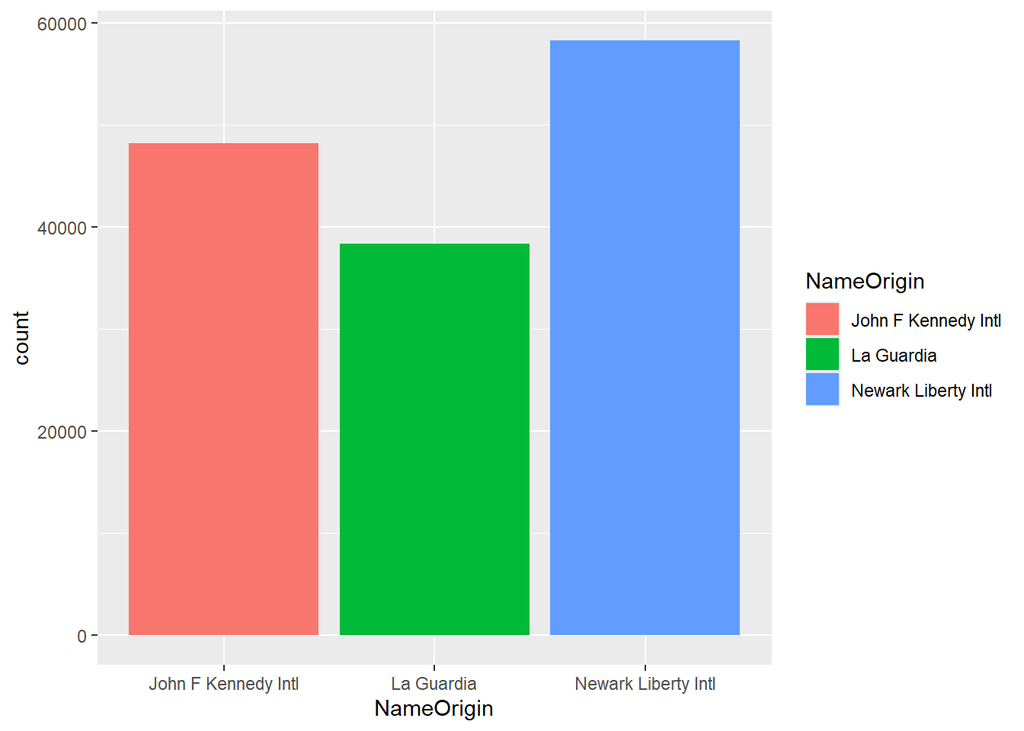

```r
ggplot(aes(x=NameOrigin, fill=NameOrigin), data=FlightsJoined) +
  geom_bar()
```

# 9 Troubleshooting & FAQ

# 10 Pre-Submission Checklist

- Does the document render to HTML without errors?
- Is the Table of Contents visible and correctly numbered?
- Does the text include at least one reference to Equation 1?
- Are all figures and tables properly captioned and referenced (e.g., “As seen in Figure 1…”)?
- Have you removed any “empty” code chunks or experimental code?

# 11 Conclusion